# Linear regressions

Michele Scandola

2020-08-16

Linear regression is not difficult, basically we are trying to estimate a line that efficiantly interpolates our data.

However, how it works?

## Independent and Dependent variables

Linear regression try to estimate the parameters $\beta$ (independent variables) that allow to better “explain the variance” of observations (dependent variable).

The *dependent variable* is the observation that we postulate being shaped / modulated / caused by our *independent variables*.

This means that we are not looking for *correlations* between the *dependent* and *independent* variables, because we assume that the *dependent* depends (sorry…) from the *independent* variables. Converserly, *correlations* do not assume that a variable causes the modification of another variable. In fact, in the correlation case, it is an error speaking of *dependent* and *independent* variables.

## The linear regression formula

Therefore, we try to estimate the *unknown vector of parameters* $\beta$ in this formula $y = X \beta + \epsilon$ trying to minimize $\epsilon$, that is our error term.

$\beta$ could also be named coefficients, fixed effects, regressors, etc…

In linear models the error term $\epsilon$ should be distributed along a normal distribution with mean 0 and standard deviation 1 $\epsilon \sim N(0, 1)$.

The $X$ matrix represents the contrast matrix where all our independent data are stored: covariates and factors.

## Estimation of the unknown vector of $\beta$s

Usually the estimation of the $\beta$s can be computed with one ot hese three algorythms:

1. Ordinary Least Square estimation (OLS)
2. Maximum Likelihood estimation (ML)
3. Restricted (or Residual) Maximum Likelihood estimation (REML)

### Ordinary Least Square estimation (OLS)

The idea is to find the coefficients that describe the line whose difference between the fitted / predicted data (i.e. the estimation of the observed data that are obtained by using the fitted model) and the observed / dependent data is minimal.

Namely, $\beta = arg~min~S(\beta)$

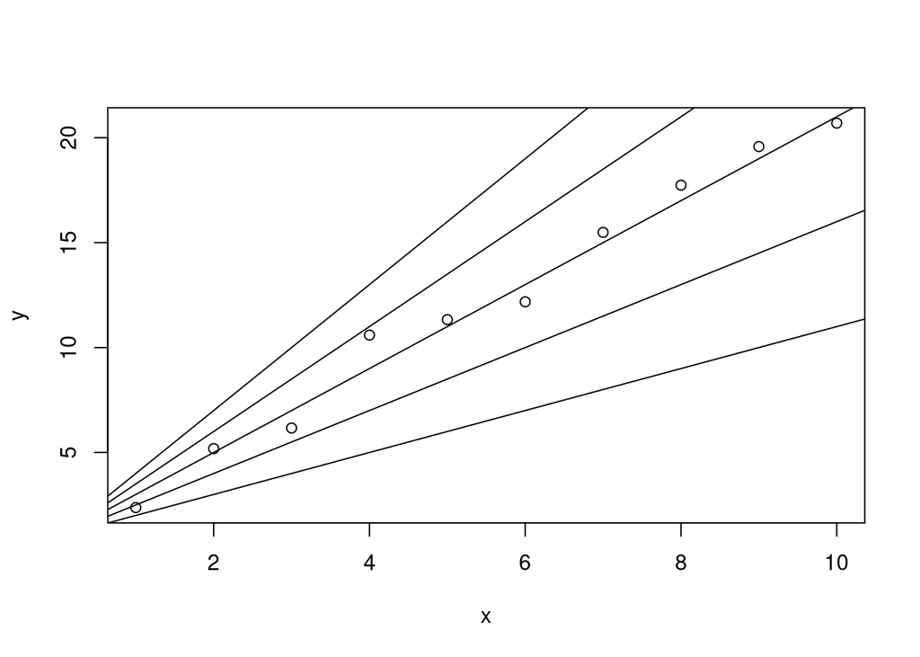

```r
## creating the data
set.seed( 1 )
# independent variable
x <- 1:10
#   beta0 + i.v. * beta1 + epsilon
y <- 1 + x * 2 + rnorm( n = 10 )

## plotting the data
plot( x , y )
abline(a = 1, b = 2)
abline(a = 1, b = 1.5)
abline(a = 1, b = 2.5)
abline(a = 1, b = 1)
abline(a = 1, b = 3)
```

```r
d <- ( y - 1 + x * 2 ) / 2
```